# **Week 3 Short Answer Questions**

## Yunjae Choi

Compiled on Tue Mar 14 22:50:38 2017.

### Chapter 5

##### Problem 5.1

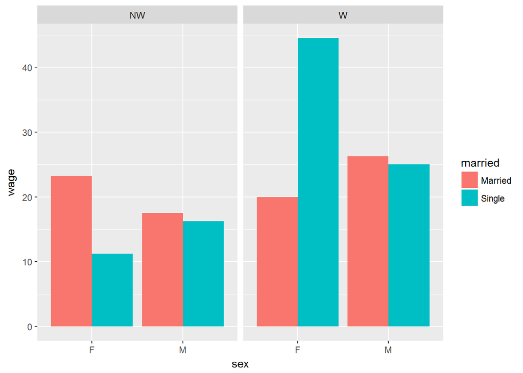

```r
ggplot(data=CPS85,
       aes(x=sex, y=wage, fill=married)) +
  geom_bar(stat='identity', position='dodge', width=.9) +
  facet_wrap(~race, ncol=3)
```

##### Problem 5.2

```r
HappinessIndex %>%
WorldMap(key="country", fill="corruption")
```

```
## Mapping API still under development and may change in future releases.
```

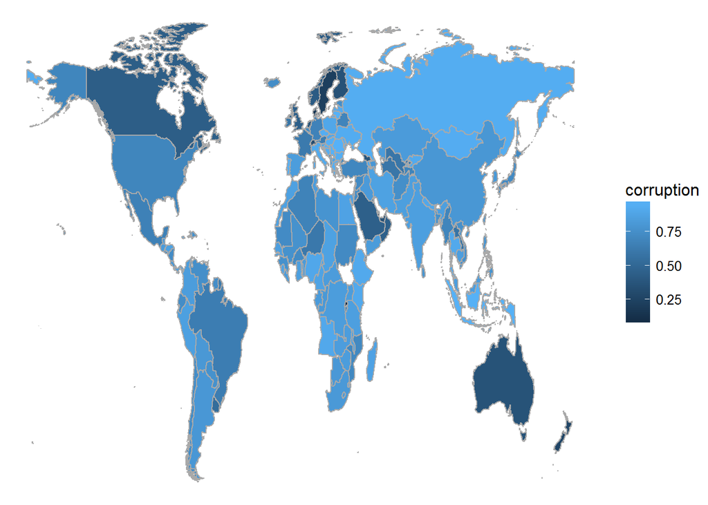

### Chapter 6

##### Problem 6.5

```
b
```

##### Problem 6.6

```
d
```

##### Problem 6.7

```
c
```

##### Problem 6.8

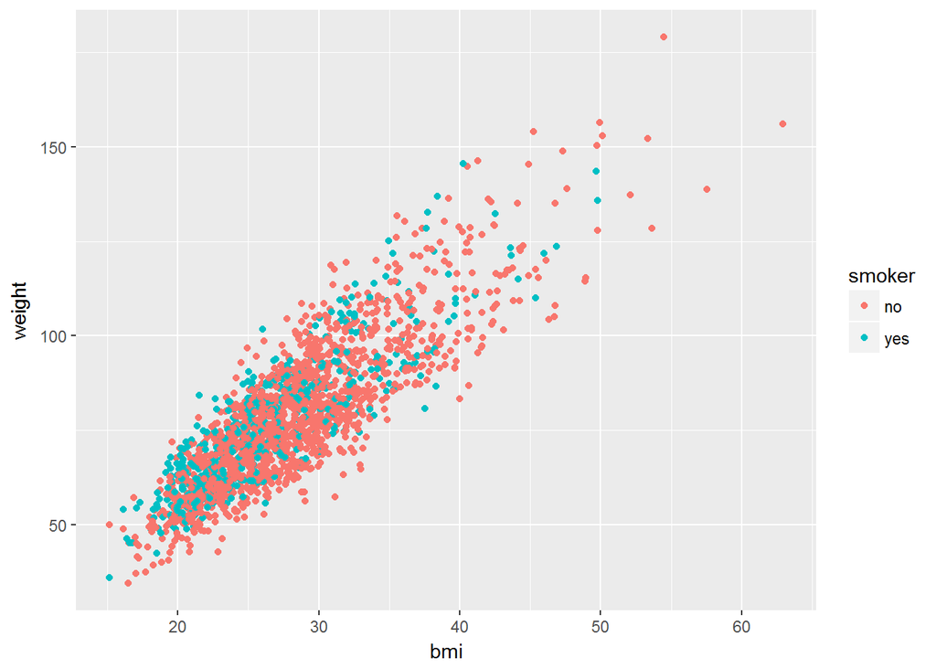

```r
Small <-
NCHS %>%
  sample_n(size=5000)
Small <- na.omit(Small)
Small$smoker <- factor(Small$smoker,labels=c("no","yes"))
ggplot(data=Small,aes(x=bmi,y=weight))+geom_point()+aes(colour=smoker)
```

### Chapter 7

##### Problem 7.1

1. Find the average of one of the variables.

   ```
   summarise()
   ```

2. Add a new column that is the ratio between two variables.

   ```
   mutate()
   ```

3. Sort the cases in descending order of a variable.

   ```
   arrange()
   ```

4. Create a new data table that includes only those cases that meet a criterion.

   ```
   filter()
   ```

5. Form a data table with three categorical variables A, B, & C, and a quantitative variable X, produce an output that has the same cases but only the variables A and X.

   ```
   select()
   ```

6. From a data table with three categorical variables A, B, & C, and a quantitative variable X, produce an output that has a separate case for each of the combinations of the levels of A and B. (Hint: It might be easier to see the answer if the problem statement added, “and gives the maximum value of X over all the cases that have a given combination of A and B.” )

   ```
   group_by() and summarise()
   ```

##### Problem 7.4

1. What’s Wrong:

   ```
   Quotation marks around "First"; it's a variable and the data is from Minneapolis2013
   ```

   Should Be:

```r
Minneapolis2013 %>%
  group_by(First) %>%
  summarise(votesReceived = n())
```

```
## # A tibble: 38 × 2
##                          First votesReceived
##                          <chr>         <int>
## 1   ABDUL M RAHAMAN "THE ROCK"           338
## 2            ALICIA K. BENNETT           351
## 3                 BETSY HODGES         28935
## 4                    BILL KAHN            97
## 5        BOB "AGAIN" CARNEY JR            56
## 6                     BOB FINE          2094
## 7                   CAM WINTON          7511
## 8         CAPTAIN JACK SPARROW           264
## 9            CHRISTOPHER CLARK           188
## 10 CHRISTOPHER ROBIN ZIMMERMAN           170
## # ... with 28 more rows
```

2. What’s Wrong:

   ```
   Cannot have the assigned object name as the argument inside a function
   ```

   Should Be:

```r
Tmp <- group_by(BabyNames, year, sex) %>%
  summarise(totalBirths = sum(count))
Tmp
```

```
## Source: local data frame [268 x 3]
## Groups: year [?]
##
##     year   sex totalBirths
##    <int> <chr>       <int>
## 1   1880     F       90993
## 2   1880     M      110491
## 3   1881     F       91954
## 4   1881     M      100746
## 5   1882     F      107850
## 6   1882     M      113687
## 7   1883     F      112322
## 8   1883     M      104630
## 9   1884     F      129022
## 10  1884     M      114446
## # ... with 258 more rows
```

3. What’s Wrong:

   ```
   Cannot repeat data set
   ```

   Should Be:

```r
Tmp <- group_by(BabyNames, year, sex) %>%
  summarise(totalBirths = sum(count))
Tmp
```

```
## Source: local data frame [268 x 3]
## Groups: year [?]
##
##     year   sex totalBirths
##    <int> <chr>       <int>
## 1   1880     F       90993
## 2   1880     M      110491
## 3   1881     F       91954
## 4   1881     M      100746
## 5   1882     F      107850
## 6   1882     M      113687
## 7   1883     F      112322
## 8   1883     M      104630
## 9   1884     F      129022
## 10  1884     M      114446
## # ... with 258 more rows
```

##### Problem 7.5

```r
tablea <- BabyNames %>%
  arrange (sex, count) %>%
  head(6)
tablea
```

```
##        name sex count year
## 1    Adelle   F     5 1880
## 2     Adina   F     5 1880
## 3  Adrienne   F     5 1880
## 4 Albertine   F     5 1880
## 5      Alys   F     5 1880
## 6       Ana   F     5 1880
```

```r
tableb <- BabyNames %>%
  filter(sex == "F") %>%
  head(6)
tableb
```

```
##        name sex count year
## 1      Mary   F  7065 1880
## 2      Anna   F  2604 1880
## 3      Emma   F  2003 1880
## 4 Elizabeth   F  1939 1880
## 5    Minnie   F  1746 1880
## 6  Margaret   F  1578 1880
```

```r
tablec <- BabyNames %>%
  filter(sex == "M", count > 10) %>%
  head(6)
tablec
```

```
##      name sex count year
## 1    John   M  9655 1880
## 2 William   M  9532 1880
## 3   James   M  5927 1880
## 4 Charles   M  5348 1880
## 5  George   M  5126 1880
## 6   Frank   M  3242 1880
```

```r
tabled <- BabyNames %>%
  summarise( total= sum(count) ) %>%
  head(6)
tabled
```

```
##       total
## 1 333417770
```

```r
tablee <- BabyNames %>%
  select(name, count) %>%
  head(6)
tablee
```

```
##        name count
## 1      Mary  7065
## 2      Anna  2604
## 3      Emma  2003
## 4 Elizabeth  1939
## 5    Minnie  1746
## 6  Margaret  1578
```

##### Problem 7.7

1. BabyNames is used twice.

   Should Be:

```r
BabyNames %>%
group_by(year, sex) %>%
summarise(total = sum(count))
```

```
## Source: local data frame [268 x 3]
## Groups: year [?]
##
##     year   sex  total
##    <int> <chr>  <int>
## 1   1880     F  90993
## 2   1880     M 110491
## 3   1881     F  91954
## 4   1881     M 100746
## 5   1882     F 107850
## 6   1882     M 113687
## 7   1883     F 112322
## 8   1883     M 104630
## 9   1884     F 129022
## 10  1884     M 114446
## # ... with 258 more rows
```

2. ZipGeography is a dataset, not an assignment name. There’s no data referring to this object.

   Should Be:

```r
ZipGeography %>%
  group_by(State) %>%
  summarise(pop = sum(Population))
```

```
## # A tibble: 53 × 2
##            State   pop
##           <fctr> <dbl>
## 1                   NA
## 2  Massachusetts    NA
## 3  New Hampshire    NA
## 4       New York    NA
## 5   Rhode Island    NA
## 6          Maine    NA
## 7        Vermont    NA
## 8    Connecticut    NA
## 9     New Jersey    NA
## 10  Pennsylvania    NA
## # ... with 43 more rows
```

3. assignment symbol used instead of a chaining syntax

   Should Be:

```r
Minneapolis2013 %>%
  group_by(First) %>%
  summarise(voteReceived = n())
```

```
## # A tibble: 38 × 2
##                          First voteReceived
##                          <chr>        <int>
## 1   ABDUL M RAHAMAN "THE ROCK"          338
## 2            ALICIA K. BENNETT          351
## 3                 BETSY HODGES        28935
## 4                    BILL KAHN           97
## 5        BOB "AGAIN" CARNEY JR           56
## 6                     BOB FINE         2094
## 7                   CAM WINTON         7511
## 8         CAPTAIN JACK SPARROW          264
## 9            CHRISTOPHER CLARK          188
## 10 CHRISTOPHER ROBIN ZIMMERMAN          170
## # ... with 28 more rows
```

4. all order backward AND “>” should be used, not “<”

   Should Be:

```r
Minneapolis2013 %>% group_by(First) %>% summarise(votesReceived = n())
```

```
## # A tibble: 38 × 2
##                          First votesReceived
##                          <chr>         <int>
## 1   ABDUL M RAHAMAN "THE ROCK"           338
## 2            ALICIA K. BENNETT           351
## 3                 BETSY HODGES         28935
## 4                    BILL KAHN            97
## 5        BOB "AGAIN" CARNEY JR            56
## 6                     BOB FINE          2094
## 7                   CAM WINTON          7511
## 8         CAPTAIN JACK SPARROW           264
## 9            CHRISTOPHER CLARK           188
## 10 CHRISTOPHER ROBIN ZIMMERMAN           170
## # ... with 28 more rows
```

##### Problem 7.11

1. column headings will look like:
   1. two levels of sex
   2. total counts for each sex
   3. mean age of each group (sex)
2. column headings will look like:
   1. All levels of diagnosis
   2. total counts for each level of diagnosis
   3. mean age of each level of diagnosis
3. column headings will look like:
   1. the first two: two levels of sex, each divided by the levels of diagnosis
   2. total counts of each group (sex) subdivided by diagnosis
   3. mean age of for each group (sex) subdivided by diagnosis
4. column headings will look like:
   1. the first two: all levels of age, each divided by the levels of diagnosis
   2. total counts of each age subdivided by diagnosis
   3. mean age of for each age subdivided by diagnosis
5. column headings will look like:
   1. age
   2. total counts for each age
   3. mean age of the first column’s age which is the same as age

##### Problem 7.12

1. Count the number of cases in a data table.

   ```
   nrow()
   ```

2. List the names of the variables in a data table.

   ```
   variable.names(data)
   OR
   names()
   ```

3. For data tables in an R package, display the documentation (“codebook”) for the data table.

   ```
   help(data)
   ```

4. Load a package into your R session.

   ```
   library(package)
   ```

5. Mark a data table as grouped by one or more categorical variables.

   ```
   group_by()
   ```

6. Add up, group-by-group, a quantitative variable in a data table.

   ```
   summarise( quantVarHeading = sum(quantvar))
   ```